# Adult Census Income

**Predict whether income exceeds $50K/yr based on census data**

This data was extracted from the 1994 Census bureau database (US) and is uploaded by "UCI Machine Learning" on kaggle. The aim is to determine whether a person makes over $50K a year.

Link to [Kaggle Dataset](https://www.kaggle.com/uciml/adult-census-income)

My objective of creating this kernel is to see how **neural network** performs on this dataset as compared to relatively simpler methods (as tried in many kernels) and also to try out how **GridSearch** method with **Keras** using **Keras Wrapper for Scikit-learn**

**Content:**

1. Data Exploration (EDA + Data Manipulation)
2. Data Preprocessing
3. Modeling
4. Predictions
5. Conclusion/Comments

Let's get Started!

Importing required modules

```python
import numpy as np
import pandas as pd
from matplotlib import rcParams
import seaborn as sns
import matplotlib.pyplot as plt

from sklearn.model_selection import train_test_split, GridSearchCV
from sklearn.preprocessing import MinMaxScaler, StandardScaler
from sklearn.metrics import confusion_matrix

from keras.models import Sequential, Model, load_model
from keras.layers import Dense, Activation, Input, Dropout
from keras.layers.normalization import BatchNormalization
from keras.utils import to_categorical
from keras.regularizers import l2
from keras import optimizers
from keras.wrappers.scikit_learn import KerasClassifier
from keras.callbacks import EarlyStopping, ModelCheckpoint

import tensorflow as tf

import warnings
warnings.filterwarnings("ignore", category=DeprecationWarning)
```

```python
import time
start_time = time.time()
```

Setting up seed for reproducible results

```python
np.random.seed(42)
tf.random.set_seed(42)
```

Reading data file

```python
data_all = pd.read_csv("adult.csv")
```

Take a peek at the data, see what columns are present and the data types, also check if headers are picked correctly

```python
data_all.head()
```

|  | age | workclass | fnlwgt | education | education.num | marital.status | occupation | relationship | race | sex | capital.gain | capital.loss | hours.per.week | native.country | income |
| --- | --- | --- | --- | --- | --- | --- | --- | --- | --- | --- | --- | --- | --- | --- | --- |
| 0 | 90 | ? | 77053 | HS-grad | 9 | Widowed | ? | Not-in-family | White | Female | 0 | 4356 | 40 | United-States | <=50K |
| 1 | 82 | Private | 132870 | HS-grad | 9 | Widowed | Exec-managerial | Not-in-family | White | Female | 0 | 4356 | 18 | United-States | <=50K |
| 2 | 66 | ? | 186061 | Some-college | 10 | Widowed | ? | Unmarried | Black | Female | 0 | 4356 | 40 | United-States | <=50K |
| 3 | 54 | Private | 140359 | 7th-8th | 4 | Divorced | Machine-op-inspct | Unmarried | White | Female | 0 | 3900 | 40 | United-States | <=50K |
| 4 | 41 | Private | 264663 | Some-college | 10 | Separated | Prof-specialty | Own-child | White | Female | 0 | 3900 | 40 | United-States | <=50K |

Hmm... looks like we have '?' character in data for missing values, we will need to replace that

Checking how many (Rows, Columns) are present in data

```python
data_all.shape
```

```
(32561, 15)
```

replacing '?' with NaN for now, it would be easier to fill NaN later with other resonable estimates

```python
data_all.replace('?',np.nan, inplace=True)
```

Checking number of classes and class distribution, we should check if our classes are balanced or skewed, it would help us choose correct performance metric for evaluating model

```python
pd.value_counts(data_all['income'])/data_all['income'].count()*100
```

```
<=50K    75.919044
>50K     24.080956
Name: income, dtype: float64
```

We can see that there are **two classes** the **classes are skewed.**

Will choose **F1-Score** (Precision and Recall) as the performance metric for our model

Let's look at data characteristics in bit more detail, and look for potential outliers in the data

```python
data_all.describe(include="all").T
```

|  | count | unique | top | freq | mean | std | min | 25% | 50% | 75% | max |
| --- | --- | --- | --- | --- | --- | --- | --- | --- | --- | --- | --- |
| age | 32561 | NaN | NaN | NaN | 38.5816 | 13.6404 | 17 | 28 | 37 | 48 | 90 |
| workclass | 30725 | 8 | Private | 22696 | NaN | NaN | NaN | NaN | NaN | NaN | NaN |
| fnlwgt | 32561 | NaN | NaN | NaN | 189778 | 105550 | 12285 | 117827 | 178356 | 237051 | 1.48470e+06 |
| education | 32561 | 16 | HS-grad | 10501 | NaN | NaN | NaN | NaN | NaN | NaN | NaN |
| education.num | 32561 | NaN | NaN | NaN | 10.0807 | 2.57272 | 1 | 9 | 10 | 12 | 16 |
| marital.status | 32561 | 7 | Married-civ-spouse | 14976 | NaN | NaN | NaN | NaN | NaN | NaN | NaN |
| occupation | 30718 | 14 | Prof-specialty | 4140 | NaN | NaN | NaN | NaN | NaN | NaN | NaN |
| relationship | 32561 | 6 | Husband | 13193 | NaN | NaN | NaN | NaN | NaN | NaN | NaN |
| race | 32561 | 5 | White | 27816 | NaN | NaN | NaN | NaN | NaN | NaN | NaN |
| sex | 32561 | 2 | Male | 21790 | NaN | NaN | NaN | NaN | NaN | NaN | NaN |
| capital.gain | 32561 | NaN | NaN | NaN | 1077.65 | 7385.29 | 0 | 0 | 0 | 0 | 99999 |
| capital.loss | 32561 | NaN | NaN | NaN | 87.3038 | 402.96 | 0 | 0 | 0 | 0 | 4356 |
| hours.per.week | 32561 | NaN | NaN | NaN | 40.4375 | 12.3474 | 1 | 40 | 40 | 45 | 99 |
| native.country | 31978 | 41 | United-States | 29170 | NaN | NaN | NaN | NaN | NaN | NaN | NaN |
| income | 32561 | 2 | <=50K | 24720 | NaN | NaN | NaN | NaN | NaN | NaN | NaN |

Looks like Workclass, Occupation and native.country has NaN values  
We will use mode (most occuring) as imputing method to fill these NaNs

**Age** seem alright, minimum is 17 and maximum is 90 (who's still working at 90?)  
**hours.per.week** - minimum is only 1 ? We will check this.. could be an outlier if salary is >50K

```python
data_all[(data_all['hours.per.week'] <= 4) & (data_all['income'] == '>50K')].sort_values(by='education.num')
```

|  | age | workclass | fnlwgt | education | education.num | marital.status | occupation | relationship | race | sex | capital.gain | capital.loss | hours.per.week | native.country | income |
| --- | --- | --- | --- | --- | --- | --- | --- | --- | --- | --- | --- | --- | --- | --- | --- |
| 8702 | 32 | NaN | 134886 | HS-grad | 9 | Married-civ-spouse | NaN | Wife | White | Female | 0 | 0 | 2 | United-States | >50K |
| 21709 | 65 | NaN | 76043 | HS-grad | 9 | Married-civ-spouse | NaN | Husband | White | Male | 0 | 0 | 1 | United-States | >50K |
| 24836 | 70 | NaN | 148065 | Some-college | 10 | Married-civ-spouse | NaN | Husband | White | Male | 0 | 0 | 4 | United-States | >50K |
| 28235 | 78 | Self-emp-not-inc | 82815 | Some-college | 10 | Married-civ-spouse | Craft-repair | Husband | White | Male | 0 | 0 | 3 | United-States | >50K |
| 1767 | 67 | Self-emp-not-inc | 431426 | Assoc-acdm | 12 | Married-civ-spouse | Exec-managerial | Wife | White | Female | 20051 | 0 | 4 | United-States | >50K |
| 15454 | 61 | NaN | 198686 | Assoc-acdm | 12 | Married-civ-spouse | NaN | Husband | White | Male | 0 | 0 | 2 | United-States | >50K |
| 15549 | 79 | NaN | 100881 | Assoc-acdm | 12 | Married-civ-spouse | NaN | Wife | White | Female | 0 | 0 | 2 | United-States | >50K |
| 19384 | 36 | Private | 183902 | Bachelors | 13 | Married-civ-spouse | Prof-specialty | Wife | White | Female | 0 | 0 | 4 | United-States | >50K |
| 1773 | 67 | Self-emp-not-inc | 148690 | Masters | 14 | Widowed | Prof-specialty | Not-in-family | White | Male | 18481 | 0 | 2 | United-States | >50K |
| 1917 | 38 | NaN | 70282 | Masters | 14 | Married-civ-spouse | NaN | Wife | Black | Female | 15024 | 0 | 2 | United-States | >50K |
| 22128 | 62 | NaN | 378239 | Masters | 14 | Married-civ-spouse | NaN | Husband | White | Male | 0 | 0 | 2 | United-States | >50K |
| 30218 | 47 | Private | 158451 | Masters | 14 | Married-civ-spouse | Prof-specialty | Wife | White | Female | 0 | 0 | 2 | United-States | >50K |
| 31528 | 61 | NaN | 584259 | Masters | 14 | Married-civ-spouse | NaN | Husband | White | Male | 0 | 0 | 2 | United-States | >50K |
| 4396 | 58 | State-gov | 109567 | Doctorate | 16 | Married-civ-spouse | Prof-specialty | Husband | White | Male | 0 | 0 | 1 | United-States | >50K |

let's fill all missing values with `mode`

```python
# fill values
print(data_all['workclass'].mode())
print(data_all['occupation'].mode())
print(data_all['native.country'].mode())
data_all['workclass'].fillna(data_all['workclass'].mode()[0], inplace=True)
data_all['occupation'].fillna(data_all['occupation'].mode()[0], inplace=True)
data_all['native.country'].fillna(data_all['native.country'].mode()[0], inplace=True)
```

```
0    Private
dtype: object
0    Prof-specialty
dtype: object
0    United-States
dtype: object
```

Final check if we still have any NaN's in our data

```python
data_all.info()
```

```
<class 'pandas.core.frame.DataFrame'>
RangeIndex: 32561 entries, 0 to 32560
Data columns (total 15 columns):
 #   Column          Non-Null Count  Dtype
---  ------          --------------  -----
 0   age             32561 non-null  int64
 1   workclass       32561 non-null  object
 2   fnlwgt          32561 non-null  int64
 3   education       32561 non-null  object
 4   education.num   32561 non-null  int64
 5   marital.status  32561 non-null  object
 6   occupation      32561 non-null  object
 7   relationship    32561 non-null  object
 8   race            32561 non-null  object
 9   sex             32561 non-null  object
 10  capital.gain    32561 non-null  int64
 11  capital.loss    32561 non-null  int64
 12  hours.per.week  32561 non-null  int64
 13  native.country  32561 non-null  object
 14  income          32561 non-null  object
dtypes: int64(6), object(9)
memory usage: 3.7+ MB
```

## Data Exploration

Now we will do some basic **EDA**, we will visualize independent variable against dependent and try to determine some relationships. We will look out for any outliers or anything out of ordinary. We will also do some **feature engineering** steps (clubbing similar classes, therby reducing features dimension)

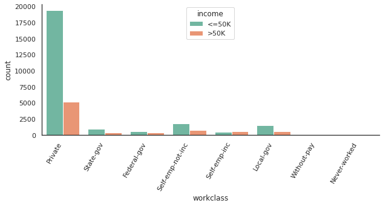

```python
sns.set(rc={'figure.figsize':(10,4)})
sns.set_style("white")
g = sns.countplot(x="workclass",hue="income", data=data_all, palette="Set2")
sns.despine()
g = g.set_xticklabels(g.get_xticklabels(), rotation=60, horizontalalignment='right')
```

**Observation 1:** Most of the employess are employed in Private sector and looks like people who are self employed (inc - i believe registered firms) are more likely to earn >50K a year  
In general, count of people earning <=50K is more than count of people earning more

Let's see some numbers - what percentage of people in each class earns more than 50K a year

```python
data_all[data_all['income'] == '>50K']['workclass'].value_counts()/data_all['workclass'].value_counts()
```

```
Federal-gov         0.386458
Local-gov           0.294792
Never-worked             NaN
Private             0.210093
Self-emp-inc        0.557348
Self-emp-not-inc    0.284927
State-gov           0.271957
Without-pay              NaN
Name: workclass, dtype: float64
```

We will also club together some of the classes based on above information

```python
data_all.replace({'workclass':{'Federal-gov':'fed_gov',
                               'State-gov':'gov', 'Local-gov':'gov', 'Self-emp-not-inc':'gov',
                               'Without-pay':'unemployed','Never-worked':'unemployed',
                               'Self-emp-inc':'self-emp'}}
                 ,inplace=True)
# 'Self-emp-not-inc' is put in same class as 'State-gov' as the proportion of people earning >50K is same
# ideally we should check relationship with other dependent variables too
# (e.g. is age, education, hours.per.week distribution also same for 'Self-emp-not-inc' and 'State-gov' and 'local-gov',
# if yes then we can combine classes else we should keep it as a separate class)
# before deciding to put in same class but we will keep things simple now
```

Occupation vs Income

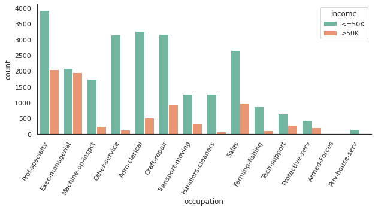

```python
sns.set(rc={'figure.figsize':(10,4)})
sns.set_style("white")
g = sns.countplot(x="occupation",hue="income", data=data_all, palette="Set2")
sns.despine()
g = g.set_xticklabels(g.get_xticklabels(), rotation=60, horizontalalignment='right')
```

Let's see some actual numbers

```python
data_all[data_all['income'] == '>50K']['occupation'].value_counts()/data_all['occupation'].value_counts()
```

```
Adm-clerical         0.134483
Armed-Forces         0.111111
Craft-repair         0.226641
Exec-managerial      0.484014
Farming-fishing      0.115694
Handlers-cleaners    0.062774
Machine-op-inspct    0.124875
Other-service        0.041578
Priv-house-serv      0.006711
Prof-specialty       0.342637
Protective-serv      0.325116
Sales                0.269315
Tech-support         0.304957
Transport-moving     0.200376
Name: occupation, dtype: float64
```

We will again group some classes based on above numbers

```python
data_all.replace({'occupation':{'Exec-managerial':'premium_pay',
                                'Prof-specialty':'good_pay','Protective-serv':'good_pay', 'Tech-support':'good_pay',
                                'Craft-repair':'normal_pay', 'Sales':'normal_pay','Transport-moving':'normal_pay',
                                'Adm-clerical':'low_pay','Armed-Forces':'low_pay','Farming-fishing':'low_pay','Machine-op-inspct':'low_pay',
                                'Other-service':'poor_pay', 'Handlers-cleaners':'poor_pay', 'Priv-house-serv':'poor_pay'}},inplace=True)
```

Education vs Income

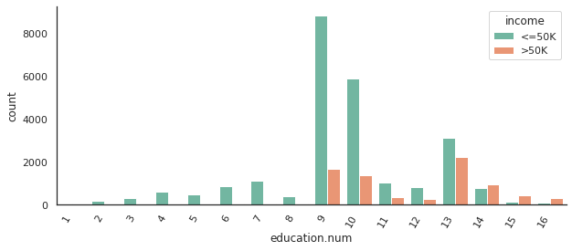

```python
sns.set(rc={'figure.figsize':(10,4)})
sns.set_style("white")
g = sns.countplot(x="education.num", hue="income", data=data_all, palette="Set2")
sns.despine()
g = g.set_xticklabels(g.get_xticklabels(), rotation=60, horizontalalignment='right')
```

So proportion of people earning > 50K is more for highly educated people... only if I knew before ;)

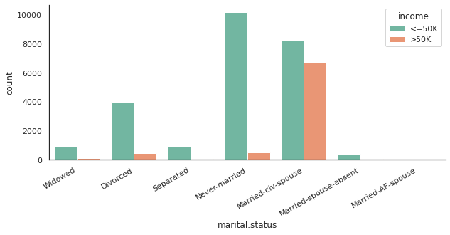

```python
sns.set(rc={'figure.figsize':(10,4)})
sns.set_style("white")
g = sns.countplot(x="marital.status",hue="income", data=data_all, palette="Set2")
sns.despine()
g = g.set_xticklabels(g.get_xticklabels(), rotation=30, horizontalalignment='right')
```

Not quite sure what to conclude.. seems like people happily married (or let's just say married) have higher chances of earning > 50K as compared to other (unhappy ?) people.. doesn't look quite intutive to me though  
'Never-married' people are probably younger folks and that's why they earn less

Again, we will group some classes into one

```python
data_all.replace({'marital.status':{'Never-married':'single','Divorced':'single','Separated':'single',
                                   'Widowed':'single','Married-spouse-absent':'single','Married-AF-spouse':'single',
                                   'Married-civ-spouse':'married'}},inplace=True)
```

Gender vs Income

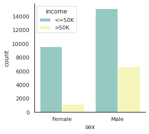

```python
sns.set(rc={'figure.figsize':(4,4)})
sns.set_style("white")
sns.countplot(x="sex",hue="income", data=data_all, palette="Set3")
sns.despine()
```

We can see the pay gap between genders, proportion of females earning > 50K is less as compared to males

Do females earn more at higer age as compared to males?

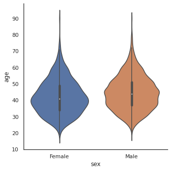

```python
sns.catplot(x="sex", y="age", kind="violin", inner="box", data=data_all[data_all['income'] == '>50K'], orient="v")
```

Doesn't quite look like the case, both male and female have approximately same median age when they start to earn > 50K

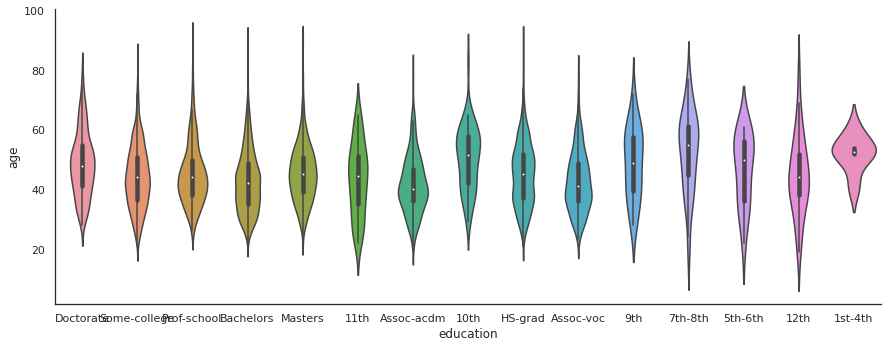

```python
sns.catplot(x="education", y="age", kind="violin", inner="box"
            , data=data_all[data_all['income'] == '>50K'], orient="v", aspect=2.5, height=5)
```

We can see that less educated people earn > 50K/year at an older age as compared to others

Is there any pay gap between people from different races ?

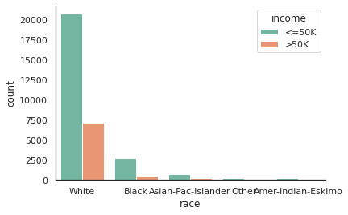

```python
sns.set(rc={'figure.figsize':(6,4)})
sns.set_style("white")
sns.countplot(x="race", hue="income", data=data_all, palette="Set2")
sns.despine()
```

let's see some numbers, graph isn't quite clear

```python
data_all[data_all['income'] == '>50K']['race'].value_counts()/data_all['race'].value_counts()
```

```
White                 0.255860
Black                 0.123880
Asian-Pac-Islander    0.265640
Amer-Indian-Eskimo    0.115756
Other                 0.092251
Name: race, dtype: float64
```

looks like some discrimination with black folks.. let draw a graph comparing education, age, [White, black] races and income (only > 50K)

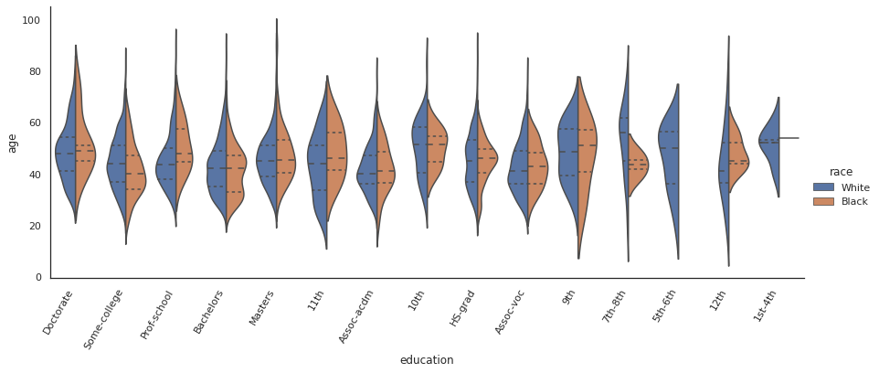

```python
g = sns.catplot(x="education", y="age", hue="race", kind="violin", inner="quartile", split=True
            , data=data_all[(data_all['income'] == '>50K') & (data_all['race'].isin(['White','Black']))], orient="v", aspect=2.5, height=5)
g = g.set_xticklabels(rotation=60, horizontalalignment='right')
```

Things kind of look alright to me.. more or less ok (with few exceptions, but that could actually be an issue iwth data too)

Let's see if low proportion os people earning >50K is because black people are more employed in low paying occupation ?

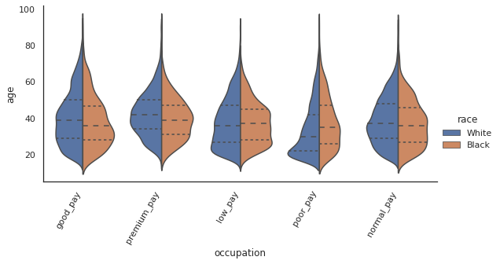

```python
g = sns.catplot(x="occupation", y="age", hue="race", kind="violin", inner="quartile", split=True
            , data=data_all[(data_all['race'].isin(['White','Black']))], orient="v", aspect=2, height=4)
g = g.set_xticklabels(rotation=60, horizontalalignment='right')
```

Also, we will group together some classes

```python
data_all.replace({'race':{'Black':'not-white', 'Asian-Pac-Islander':'not-white', 'Amer-Indian-Eskimo':'not-white'
                          ,'Other':'not-white'}}
                 , inplace=True)
```

relationship vs income

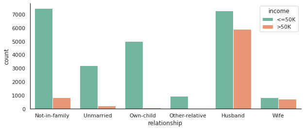

```python
sns.set(rc={'figure.figsize':(10,4)})
sns.set_style("white")
sns.countplot(x="relationship",hue="income", data=data_all, palette="Set2")
sns.despine()
```

relation case looks similar (related) to 'marital.status' field.. people happily married are husband and wife (and this graph suggests the same, people who are married have more probability of earning > 50K).. we may remove one of the feature from our model

```python
data_all.replace({'relationship':{'Husband':'family','Wife':'family','Not-in-family':'not_family','Own-child':'family',
                                  'Unmarried':'not_family','Other-relative':'not_family'}},inplace=True)
```

Much awaited Age vs Income comparision

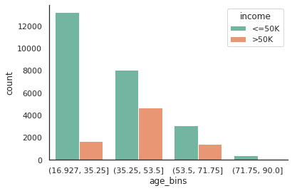

```python
data_all['age_bins'] = pd.cut(data_all['age'], bins=4)
sns.set(rc={'figure.figsize':(6,4)})
sns.set_style("white")
sns.countplot(x="age_bins",hue="income", data=data_all, palette="Set2")
sns.despine()
```

as expected, proportion of younger people earning more than 50K/year is less as compared to adult and senior people

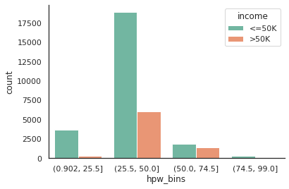

```python
data_all['hpw_bins'] = pd.cut(data_all['hours.per.week'], 4)
sns.set(rc={'figure.figsize':(6,4)})
sns.set_style("white")
sns.countplot(x="hpw_bins",hue="income", data=data_all, palette="Set2")
sns.despine()
```

simple math.. the more you work more you would earn

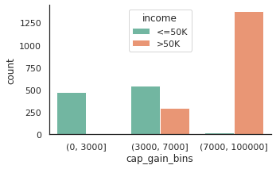

```python
data_all['cap_gain_bins'] = pd.cut(data_all['capital.gain'], [0,3000,7000,100000])
sns.set(rc={'figure.figsize':(5,3)})
sns.set_style("white")
sns.countplot(x="cap_gain_bins",hue="income", data=data_all, palette="Set2")
sns.despine()
```

capital gains field is co-related with income, more gains means more income

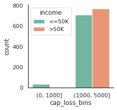

```python
data_all['cap_loss_bins'] = pd.cut(data_all['capital.loss'], [0,1000,5000])
sns.set(rc={'figure.figsize':(3,3)})
sns.set_style("white")
sns.countplot(x="cap_loss_bins",hue="income", data=data_all, palette="Set2")
sns.despine()
```

Doesn't look like same case with capital loss though, income doesn't seem to be related with capital.loss directly

Update native.country values.. using continent names rather than country names to club together classes

```python
data_all.replace({'native.country':{'China': 'asia', 'Hong': 'asia', 'India': 'asia', 'Iran': 'asia', 'Cambodia': 'asia', 'Japan': 'asia', 'Laos': 'asia', 'Philippines': 'asia', 'Vietnam': 'asia', 'Taiwan': 'asia', 'Thailand': 'asia'}},inplace=True)
data_all.replace({'native.country':{'England': 'europe', 'France': 'europe', 'Germany': 'europe', 'Greece': 'europe', 'Holand-Netherlands': 'europe', 'Hungary': 'europe', 'Ireland': 'europe', 'Italy': 'europe', 'Poland': 'europe', 'Portugal': 'europe', 'Scotland': 'europe', 'Yugoslavia': 'europe'}},inplace=True)
data_all.replace({'native.country':{'Canada':'NAmerica','United-States':'NAmerica','Puerto-Rico':'NAmerica'}},inplace=True)
data_all.replace({'native.country':{'Columbia': 'SA', 'Cuba': 'SA', 'Dominican-Republic': 'SA', 'Ecuador': 'SA', 'El-Salvador': 'SA', 'Guatemala': 'SA', 'Haiti': 'SA', 'Honduras': 'SA', 'Mexico': 'SA', 'Nicaragua': 'SA', 'Outlying-US(Guam-USVI-etc)': 'SA', 'Peru': 'SA', 'Jamaica': 'SA', 'Trinadad&Tobago': 'SA'}},inplace=True)
data_all.replace({'native.country':{'South':'SA'}},inplace=True)
```

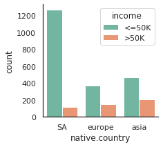

```python
# Except North America
sns.set_style("white")
sns.countplot(x="native.country",hue="income", data=data_all[data_all['native.country'] != 'NAmerica'], palette="Set2")
sns.despine()
```

No co-relation with any country.. although proportion of people from south america region earning less than 50K is more as compared to people from other region

```python
data_all.drop(columns=['age_bins','hpw_bins','cap_gain_bins','cap_loss_bins'],inplace=True)
```

## Data Preprocessing

In next few steps, we will convert categorical variables to numerical, scale numerical variables, convert target variable to binary and drop 'education' variable, we will keep all other variables

let's first convert income variable to binary 0 and 1 (as needed by model)

```python
data_all.at[data_all[data_all['income'] == '>50K'].index, 'income'] = 1
data_all.at[data_all[data_all['income'] == '<=50K'].index, 'income'] = 0
```

just check if everything got converted to 0 and 1 and class distribution is still same.. verification step

```python
pd.value_counts(data_all['income'])/data_all['income'].count()*100
```

```
0    75.919044
1    24.080956
Name: income, dtype: float64
```

let's **drop eduction** field as the same information is already presented by another numerical variable **education.num**

```python
# we will not use 'education' column as we have 'education.num'
data_all.drop(columns=['education'], inplace=True)
```

We will next do a train test split - 0.3 part for testing and rest for training  
We will `stratify` our data on 'income' so that class distribution is same in both training and test

```python
X,y = data_all.loc[:,data_all.columns != 'income'], data_all.loc[:,data_all.columns == 'income']
X_train, X_test, y_train, y_test = train_test_split(data_all.loc[:,data_all.columns != 'income']
                                                    , data_all.loc[:,data_all.columns == 'income']
                                                    , test_size=0.3, random_state=42, stratify=data_all['income'])
```

```python
X_train.shape, X_test.shape
```

```
((22792, 13), (9769, 13))
```

Scaling numerical variables  
**Tip:** Make sure to use same scale for both training and testing (meaning don't fit separately on train and test sets)

```python
#### Keep numerical
scalar_train = MinMaxScaler()
num_col_names = X_train.select_dtypes(include=['int64']).columns
num_col_df = X_train[num_col_names].copy()
scaled_num_col_df = scalar_train.fit_transform(num_col_df)
for i,j in enumerate(num_col_names):
    X_train[j] = scaled_num_col_df[:,i]

#---------------------------------
num_col_df_test = X_test[num_col_names].copy()
scaled_num_col_df = scalar_train.transform(num_col_df_test)
for i,j in enumerate(num_col_names):
    X_test[j] = scaled_num_col_df[:,i]
```

```python
X_train.head()
```

|  | age | workclass | fnlwgt | education.num | marital.status | occupation | relationship | race | sex | capital.gain | capital.loss | hours.per.week | native.country |
| --- | --- | --- | --- | --- | --- | --- | --- | --- | --- | --- | --- | --- | --- |
| 24582 | 0.150685 | Private | 0.131715 | 0.533333 | single | normal_pay | family | White | Male | 0.000000 | 0.0 | 0.479592 | NAmerica |
| 10298 | 0.095890 | gov | 0.121137 | 0.200000 | single | low_pay | family | White | Male | 0.000000 | 0.0 | 0.500000 | NAmerica |
| 16626 | 0.041096 | Private | 0.223552 | 0.600000 | single | poor_pay | family | White | Male | 0.000000 | 0.0 | 0.346939 | NAmerica |
| 11039 | 0.726027 | Private | 0.140604 | 0.600000 | single | premium_pay | not_family | White | Female | 0.000000 | 0.0 | 0.112245 | NAmerica |
| 2535 | 0.369863 | self-emp | 0.029153 | 0.600000 | married | premium_pay | family | White | Male | 0.076881 | 0.0 | 0.448980 | NAmerica |

Looks like all variables scaled perfectly

Converting rest of the variables to `category` type foe easier preprocessing in next steps

```python
category_cols = list(set(X_train.columns.tolist()) - set(num_col_names))
for col in category_cols:
    X_train[col] = X_train[col].astype('category')
    X_test[col] = X_test[col].astype('category')
```

we will now create separate binary features for each workclass type, occupation type, race type, country name and marital status

```python
X_train = pd.get_dummies(columns=category_cols, data=X_train, prefix=category_cols, prefix_sep="_",drop_first=True)

X_test = pd.get_dummies(columns=category_cols, data=X_test, prefix=category_cols, prefix_sep="_",drop_first=True)
```

Let's just see what all and how manu columns are present in our final dataset which we will use for training

```python
print(X_train.columns, X_train.shape)
```

```
Index(['age', 'fnlwgt', 'education.num', 'capital.gain', 'capital.loss',
       'hours.per.week', 'relationship_not_family', 'workclass_fed_gov',
       'workclass_gov', 'workclass_self-emp', 'workclass_unemployed',
       'sex_Male', 'occupation_low_pay', 'occupation_normal_pay',
       'occupation_poor_pay', 'occupation_premium_pay', 'native.country_SA',
       'native.country_asia', 'native.country_europe', 'marital.status_single',
       'race_not-white'],
      dtype='object') (22792, 21)
```

```python
X_train.head()
```

|  | age | fnlwgt | education.num | capital.gain | capital.loss | hours.per.week | relationship_not_family | workclass_fed_gov | workclass_gov | workclass_self-emp | workclass_unemployed | sex_Male | occupation_low_pay | occupation_normal_pay | occupation_poor_pay | occupation_premium_pay | native.country_SA | native.country_asia | native.country_europe | marital.status_single | race_not-white |
| --- | --- | --- | --- | --- | --- | --- | --- | --- | --- | --- | --- | --- | --- | --- | --- | --- | --- | --- | --- | --- | --- |
| 24582 | 0.150685 | 0.131715 | 0.533333 | 0.000000 | 0.0 | 0.479592 | 0 | 0 | 0 | 0 | 0 | 1 | 0 | 1 | 0 | 0 | 0 | 0 | 0 | 1 | 0 |
| 10298 | 0.095890 | 0.121137 | 0.200000 | 0.000000 | 0.0 | 0.500000 | 0 | 0 | 1 | 0 | 0 | 1 | 1 | 0 | 0 | 0 | 0 | 0 | 0 | 1 | 0 |
| 16626 | 0.041096 | 0.223552 | 0.600000 | 0.000000 | 0.0 | 0.346939 | 0 | 0 | 0 | 0 | 0 | 1 | 0 | 0 | 1 | 0 | 0 | 0 | 0 | 1 | 0 |
| 11039 | 0.726027 | 0.140604 | 0.600000 | 0.000000 | 0.0 | 0.112245 | 1 | 0 | 0 | 0 | 0 | 0 | 0 | 0 | 0 | 1 | 0 | 0 | 0 | 1 | 0 |
| 2535 | 0.369863 | 0.029153 | 0.600000 | 0.076881 | 0.0 | 0.448980 | 0 | 0 | 0 | 1 | 0 | 1 | 0 | 0 | 0 | 1 | 0 | 0 | 0 | 0 | 0 |

## Modeling Part

While **Neural network** in not something which is really required for this dataset, we are using it to see how much i**mprovement in accuracy** they bring (as compared to other methods tried by people in kernels on Kaggle), we also aim to show how **GridSearchCV** which is a scikit-learn method can actually be used with **Keras** and we will be using **Keras Wrapper for Scikit-learn** to achieve this.

**GriDSearchCV** is something you can use with **smaller neural network models** (small training dataset, less learnable parameters) and is **not recommended for large model** as it is **computationaly expensive** and is **not** the most **optimal** method for searching best set of parameter values. For **large models**, we can use **Bayesian Optimization** for finding best performing set of parameter values

If you want to learn more, here is a link to a great artical explaining these methods in more detail - http://krasserm.github.io/2018/03/21/bayesian-optimization/

Let's define are model structure  
We will use only 3 layes (2 hidden and one output - 16,8,1), we will use `relu` as the activation function, `Adam` as loss optimization function and `sigmoid` as the activation function for output layer.. nothing too complicated here!

```python
def model_func(activation='relu', weight_decay=1e-7, learning_rate=0.001, dropout_rate=0.3):

    model = Sequential()
    model.add(Dense(16,input_dim=X_train.shape[1], activation=activation
                    , kernel_regularizer=l2(weight_decay), kernel_initializer="glorot_normal"))
    model.add(BatchNormalization())
    model.add(Dropout(dropout_rate))
    model.add(Dense(8, activation=activation,kernel_regularizer=l2(weight_decay), kernel_initializer="normal"))
    model.add(BatchNormalization())
    model.add(Dropout(dropout_rate))
    model.add(Dense(1, activation='sigmoid',kernel_regularizer=l2(weight_decay),kernel_initializer="normal"))

    # Compile model
    adam = optimizers.Adam(lr=learning_rate)
    model.compile(loss='binary_crossentropy', optimizer=adam, metrics=['accuracy'])

    return model
```

defining our parameter grid for the GridSearch part, for keeping things simple (more importantly saving on computation cost) we are only search best values for `weight_deacy` and `learning_rate` parameters

```python
param_grid = {'weight_decay': [1e-3, 1e-4, 1e-5, 1e-6]
              , 'learning_rate': [0.03, 0.01, 0.007, 0.003, 0.001, 0.0007, 0.0003]
             }
```

Keras Wrapper - Wrapping our model with KerasClassifier (to be able to use GriSearchCV)

```python
my_model = KerasClassifier(build_fn=model_func)
```

Using GridSearchCV

```python
model = GridSearchCV(estimator=my_model, param_grid=param_grid, verbose=0)
```

Fitting training data to our model  
**Important** thing to note, I have used `epochs`=5 to save on time but you can use more `epochs`in your model

```python
model.fit(X_train, y_train, epochs=5, validation_split=0.2, batch_size=256)
```

```
Train on 14586 samples, validate on 3647 samples
```

```
GridSearchCV(cv=None, error_score=nan,
             estimator=<keras.wrappers.scikit_learn.KerasClassifier object at 0x7fa5456fc198>,
             iid='deprecated', n_jobs=None,
             param_grid={'learning_rate': [0.03, 0.01, 0.007, 0.003, 0.001,
                                           0.0007, 0.0003],
                         'weight_decay': [0.001, 0.0001, 1e-05, 1e-06]},
             pre_dispatch='2*n_jobs', refit=True, return_train_score=False,
             scoring=None, verbose=0)
```

Let's take a look at the best parameters model found

```python
print('The parameters of the best model are: ')
print(model.best_params_)
best_param = model.best_params_
```

```
The parameters of the best model are:
{'learning_rate': 0.03, 'weight_decay': 1e-05}
```

```python
print("Best: %f using %s" % (model.best_score_, model.best_params_))
means = model.cv_results_['mean_test_score']
stds = model.cv_results_['std_test_score']
#print(means, stds)
#for mean, stdev, param in zip(means, stds, params):
#    print("%f (%f) with: %r" % (mean, stdev, param))
```

```
Best: 0.843104 using {'learning_rate': 0.03, 'weight_decay': 1e-05}
```

Now that we have found best parameters, I am training model again using those parameters.. this time for a little more `epochs`, also we will use two `callbacks` - **Early Stopping** and **Model Checkpoint** to basically stop training when loss starts to increase (patience is set to 5), and save best model (with least validation loss, you can actucally use 'val_acc' as the monitor metric too, it depends on the problem statement you are solving)

```python
early_stopping = EarlyStopping(monitor='val_loss', mode='min', verbose=1, patience=5)
callback_best_model = ModelCheckpoint('best_model.h5', monitor='val_loss', mode='min', save_best_only=True)
```

```python
model_nn = model_func(weight_decay=best_param['weight_decay'], learning_rate=best_param['learning_rate'])
```

```python
model_nn.fit(X_train, y_train, batch_size=256, validation_split=0.2, epochs=50, verbose=2, callbacks=[early_stopping, callback_best_model], shuffle=True)
```

```
Train on 18233 samples, validate on 4559 samples
 - 1s - loss: 0.4037 - accuracy: 0.7988 - val_loss: 0.4656 - val_accuracy: 0.7502
 - 0s - loss: 0.3509 - accuracy: 0.8384 - val_loss: 0.3857 - val_accuracy: 0.8144
 - 0s - loss: 0.3457 - accuracy: 0.8409 - val_loss: 0.4149 - val_accuracy: 0.8147
 - 0s - loss: 0.3414 - accuracy: 0.8433 - val_loss: 0.3598 - val_accuracy: 0.8296
 - 0s - loss: 0.3383 - accuracy: 0.8441 - val_loss: 0.3578 - val_accuracy: 0.8302
 - 0s - loss: 0.3381 - accuracy: 0.8453 - val_loss: 0.3540 - val_accuracy: 0.8375
 - 0s - loss: 0.3348 - accuracy: 0.8457 - val_loss: 0.3524 - val_accuracy: 0.8353
 - 0s - loss: 0.3352 - accuracy: 0.8461 - val_loss: 0.3511 - val_accuracy: 0.8366
 - 0s - loss: 0.3325 - accuracy: 0.8467 - val_loss: 0.3617 - val_accuracy: 0.8388
 - 0s - loss: 0.3331 - accuracy: 0.8497 - val_loss: 0.3728 - val_accuracy: 0.8307
 - 0s - loss: 0.3308 - accuracy: 0.8459 - val_loss: 0.3465 - val_accuracy: 0.8377
 - 0s - loss: 0.3313 - accuracy: 0.8486 - val_loss: 0.3553 - val_accuracy: 0.8293
 - 0s - loss: 0.3339 - accuracy: 0.8440 - val_loss: 0.3642 - val_accuracy: 0.8247
 - 0s - loss: 0.3354 - accuracy: 0.8449 - val_loss: 0.3550 - val_accuracy: 0.8392
 - 0s - loss: 0.3334 - accuracy: 0.8476 - val_loss: 0.3582 - val_accuracy: 0.8322
 - 0s - loss: 0.3322 - accuracy: 0.8480 - val_loss: 0.3502 - val_accuracy: 0.8386
Epoch 00016: early stopping
```

```
<keras.callbacks.callbacks.History at 0x7fa52f913160>
```

Let's take a look at the accuracy and loss curves  
Accuracy should go up and loass should go down as number of epochs increases  
Ideally both of these curves should not fluctuate (straight type of lines), if they are fluctuating then it means we need to refine our mode (change number units, number of hidden layes, use different activation, optimization parameters, smaller/dynamic learning rate and different batch_size etc.)

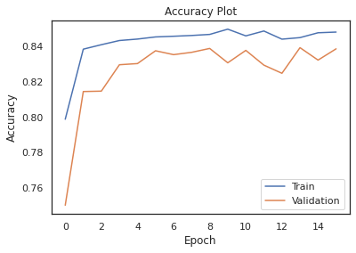

```python
# figure size in inches
rcParams['figure.figsize'] = 6,4

plt.plot(model_nn.history.history['accuracy'])
plt.plot(model_nn.history.history['val_accuracy'])
plt.title('Accuracy Plot')
plt.ylabel('Accuracy')
plt.xlabel('Epoch')
plt.legend(['Train', 'Validation'])
plt.show()
```

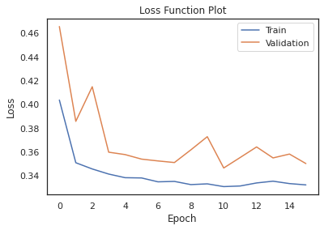

```python
plt.plot(model_nn.history.history['loss'])
plt.plot(model_nn.history.history['val_loss'])
plt.title('Loss Function Plot')
plt.ylabel('Loss')
plt.xlabel('Epoch')
plt.legend(['Train', 'Validation'])
plt.show()
```

Graphs don't look the best, We should ideally fine tune our parameters but I'll leave that up to you

## Predictions

Let's load our best model again and predict on the test set we had reserved earlier in the Data Processing step

```python
model_nn = load_model('best_model.h5')
```

```python
train_pred=model_nn.predict_classes(X_train)
test_pred = model_nn.predict_classes(X_test)
```

```python
confusion_matrix_test = confusion_matrix(y_test.astype(int).values, test_pred)
confusion_matrix_train = confusion_matrix(y_train.astype(int).values, train_pred)

print(confusion_matrix_train)
print(confusion_matrix_test)
```

```
[[15949  1354]
 [ 1989  3500]]
[[6801  616]
 [ 879 1473]]
```

Printing **train** and **test** **F1 score, precision** and **recall** values  
Values shouldn't be too far for train and test set, **big difference** in training and test set performace would indicate a **bias or variance** issue with our model

```python
Precision= confusion_matrix_train[0,0]/(confusion_matrix_train[0,0]+confusion_matrix_train[0,1])
Recall = confusion_matrix_train[0,0]/(confusion_matrix_train[0,0]+confusion_matrix_train[1,0])

print("Training Precision: ",round(Precision,2))
print("Training Recall: ",round(Recall,2))
print("Training F1 Score: ", round((2 * Precision * Recall) / (Precision + Recall),2))
print("-----------------------")
Precision= confusion_matrix_test[0,0]/(confusion_matrix_test[0,0]+confusion_matrix_test[0,1])
Recall = confusion_matrix_test[0,0]/(confusion_matrix_test[0,0]+confusion_matrix_test[1,0])
print("Test Precision: ",round(Precision,2))
print("Test Recall: ",round(Recall,2))
print("Test F1 Score: ", round((2*Precision*Recall)/(Precision + Recall), 2))
```

```
Training Precision:  0.92
Training Recall:  0.89
Training F1 Score:  0.91
-----------------------
Test Precision:  0.92
Test Recall:  0.89
Test F1 Score:  0.9
```

Oh hey, look we didn't do too bad on the test set and our model seems alright (can still be optimized though)

```python
print(time.time() - start_time)
```

```
1103.5485334396362
```

## Conclusion/Comments

- We learned how to deal with a classification problem
- We learned to use a neural network using Keras
- We learned to use GridSearchCV with Keras to search for best parameters